# Reproduce multiPLIER Figure 3 - NARES

Sehyun Oh

September 22, 2020

# Setup

In this vignette, we are reproducing Figure 3 of the [multiPLIER paper](https://www.sciencedirect.com/science/article/pii/S240547121930119X?via%3Dihub) using PCAGenomicSignatures.

## PCAmodel

To directly compare with the results from multiPLIER paper, we used the PCAmodel annotated with the same priors: bloodCellMarkersIRISDMAP, svmMarkers, and canonicalPathways.

```r
data.dir <- system.file("extdata", package = "PCAGenomicSignaturesPaper")
PCAmodel <- readRDS(file.path(data.dir, "PCAmodel_PLIERpriors.rds"))
PCAmodel
```

```
#> class: PCAGenomicSignatures
#> dim: 13934 4764
#> metadata(6): cluster size ... MeSH_freq updateNote
#> assays(1): model
#> rownames(13934): CASKIN1 DDX3Y ... CTC-457E21.9 AC007966.1
#> rowData names(0):
#> colnames(4764): PCcluster1 PCcluster2 ... PCcluster4763 PCcluster4764
#> colData names(4): PCcluster studies silhouetteWidth gsea
#> trainingData(2): PCAsummary MeSH
#> trainingData names(536): DRP000987 SRP059172 ... SRP164913 SRP188526
```

```r
updateNote(PCAmodel)
```

```
#> [1] "536 refine.bio studies/ top 90% varying genes/ GSEA with 3 priors from PLIER (bloodCellMarkersIRISDMAP, svmMarkers, and canonicalPathways)"
```

## NARES Nasal Brushings

- Expression cata is downloaded from [here](https://github.com/greenelab/multi-plier/blob/master/data/expression_data/NARES_SCANfast_ComBat_with_GeneSymbol.pcl)
- Analysis script is modified from [this](https://github.com/greenelab/multi-plier/blob/master/14-NARES_MCPcounter.Rmd)

### Expression data

NARES (Grayson et al., 2015) is a nasal brushing microarray dataset that includes patients with ANCA-associated vasculitis, patients with sarcoidosis and healthy controls among other groups and was projected into the MultiPLIER latent space.

```r
exprs <- readr::read_tsv("data/NARES_SCANfast_ComBat_with_GeneSymbol.pcl") %>%
  as.data.frame

rownames(exprs) <- exprs$GeneSymbol
dataset <- as.matrix(exprs[,3:ncol(exprs)])
dataset[1:2, 1:4]
```

```
#>            N1004       N1007        N1017       N1025
#> A1BG  0.05641348  0.06333364  0.001833597 -0.05897817
#> NAT2 -0.14980276 -0.09186388 -0.093684629 -0.06080664
```

### MCPcounter

NARES data doesn’t have any information about the cell type composition of the samples, so in the multiPLIER paper, the authors applied [MCPcounter](https://github.com/ebecht/MCPcounter/tree/a79614eee002c88c64725d69140c7653e7c379b4) ([Becht, et al. *Genome Biology*. 2016.](https://doi.org/10.1186/s13059-016-1070-5)) , which is a method for estimating cell type abundance in solid tissues.

As in multiPLIER paper, we tested if *neutrophil-associated* PCclusters from PCAmodel are well-correlated with the neutrophil estimates from MCPcounter.

#### Install MCPcounter

```r
devtools::install_github("ebecht/MCPcounter",
                         ref = "a79614eee002c88c64725d69140c7653e7c379b4",
                         subdir = "Source",
                         dependencies = TRUE)
```

#### Run MCPcounter

```r
mcp.results <- MCPcounter::MCPcounter.estimate(exprs.mat, featuresType = "HUGO_symbols")
mcp.melt <- reshape2::melt(mcp.results, varnames = c("Cell_type", "Sample"),
                           value.name = "MCP_estimate")
readr::write_tsv(mcp.melt, "data/NARES_ComBat_MCPCounter_results_tidy.tsv")
```

# EDA

## Validation

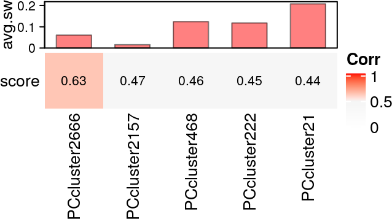

```r
val_all <- validate(dataset, PCAmodel)
validated_ind <- validatedSignatures(val_all, num.out = 5, swCutoff = 0, indexOnly = TRUE)
heatmapTable(val_all, num.out = 5, swCutoff = 0)
```

## Sample score

```r
sampleScore <- calculateScore(dataset, PCAmodel)
```

## GSEA

```r
## PCclusters containing the keyword, "neutrophil", in each GSEA result
a <- gsea(PCAmodel)
b <- sapply(a, function(x) {
  y <- x[order(x$NES, decreasing = TRUE),][1:3,]   # top 3 NES
  grep("neutrophil", y[["Description"]], ignore.case = TRUE)
  })
c <- sapply(b, length)
table(c)
```

```
#> c
#>    0    1    2
#> 4655   98   11
```

```r
## PCclusters with two keyword-containing pathways
which(c == 2)
```

```
#>    PCcluster7  PCcluster147  PCcluster172  PCcluster216  PCcluster560
#>             7           147           172           216           560
#> PCcluster1551 PCcluster1730 PCcluster1917 PCcluster2530 PCcluster2667
#>          1551          1730          1917          2530          2667
#> PCcluster2745
#>          2745
```

```r
sig_ind <- gsub("PCcluster", "", names(which(c == 2))) %>% as.numeric
```

# Interpret score

## Validated RAVs

Here, we tested the association between neutrophil count estimate of NARES data against scores from validated RAVs.

```r
## Remove Sample category "gene"
gene_ind <- which(mcp.melt$Sample == "Gene")
mcp.melt <- mcp.melt[-gene_ind,]

## Subset sampleScore to join with MCPcounter
sampleScore_sub <- sampleScore[,validated_ind] %>% as.data.frame
sampleScore_sub <- tibble::rownames_to_column(sampleScore_sub)
colnames(sampleScore_sub)[1] <- "Sample"

## Join with MCPcounter neutrophil estimates
dat <- dplyr::filter(mcp.melt, Cell_type == "Neutrophils") %>%
  dplyr::inner_join(y = sampleScore_sub, by = "Sample")

head(dat, 3)
```

```
#>     Cell_type Sample MCP_estimate PCcluster2666 PCcluster2157 PCcluster468
#> 1 Neutrophils  N1004    0.6064648    -0.3121532     0.5998012    0.6141872
#> 2 Neutrophils  N1007    1.8775036    -0.2644134    -1.2325787    0.5445723
#> 3 Neutrophils  N1017    0.6006657    -1.0547257     1.2549837   -0.2114472
#>   PCcluster222 PCcluster21
#> 1   0.09946958  0.08009604
#> 2   1.26085916  1.16034294
#> 3  -1.08045707 -0.71583837
```

RAV1551 wasn’t recovered and the most of the validated RAVs show a weak correlation with neutrophil-count estimate, implying that neutrophil count is not a major feature of the NARES dataset.

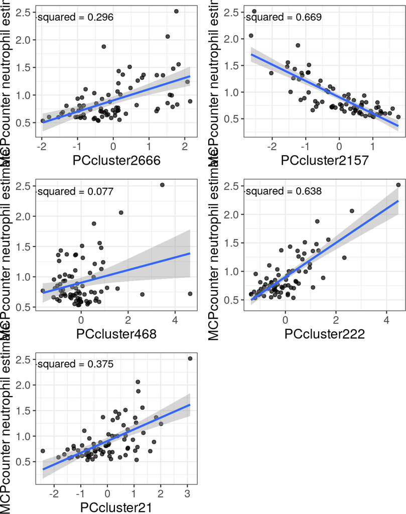

```r
plots <- list()
for (i in seq_along(validated_ind)) {
  plot <- LVScatter(dat, paste0("PCcluster", validated_ind[i]),
                    y.var = "MCP_estimate",
                    ylab = "MCPcounter neutrophil estimate")
  plots[[i]] <- plot
}

gridExtra::grid.arrange(grobs = plots, cols = 2)
```

## Significant RAVs from GSEA

Object `dat2` is a data frame with neutrophil-estimate from MCPcounter and scores assigned by significant RAVs selected by GSEA.

```r
## Subset sampleScore to join with MCPcounter
sampleScore_sub2 <- sampleScore[,sig_ind] %>% as.data.frame
sampleScore_sub2 <- tibble::rownames_to_column(sampleScore_sub2)
colnames(sampleScore_sub2)[1] <- "Sample"

## Join with MCPcounter neutrophil estimates
dat2 <- dplyr::filter(mcp.melt, Cell_type == "Neutrophils") %>%
  dplyr::inner_join(y = sampleScore_sub2, by = "Sample")

head(dat2, 3)
```

```
#>     Cell_type Sample MCP_estimate PCcluster7 PCcluster147 PCcluster172
#> 1 Neutrophils  N1004    0.6064648 -0.2540815   -0.6027338    -0.351857
#> 2 Neutrophils  N1007    1.8775036  1.8635788   -2.2385203     1.853171
#> 3 Neutrophils  N1017    0.6006657 -0.9249652    0.5691604    -1.195890
#>   PCcluster216 PCcluster560 PCcluster1551 PCcluster1730 PCcluster1917
#> 1   -0.7289638    0.5442089   -0.09409653     1.1431430    -0.3368281
#> 2    1.8184626   -1.9521744    1.91008170    -0.8570011     2.0495807
#> 3   -0.7340130    1.1191780   -0.92446139     0.2169728    -0.9805265
#>   PCcluster2530 PCcluster2667 PCcluster2745
#> 1    -0.3727521     0.2832317     0.7815207
#> 2     2.1782371    -2.7525391     0.1127065
#> 3    -0.9231144     0.2927935     0.7343962
```

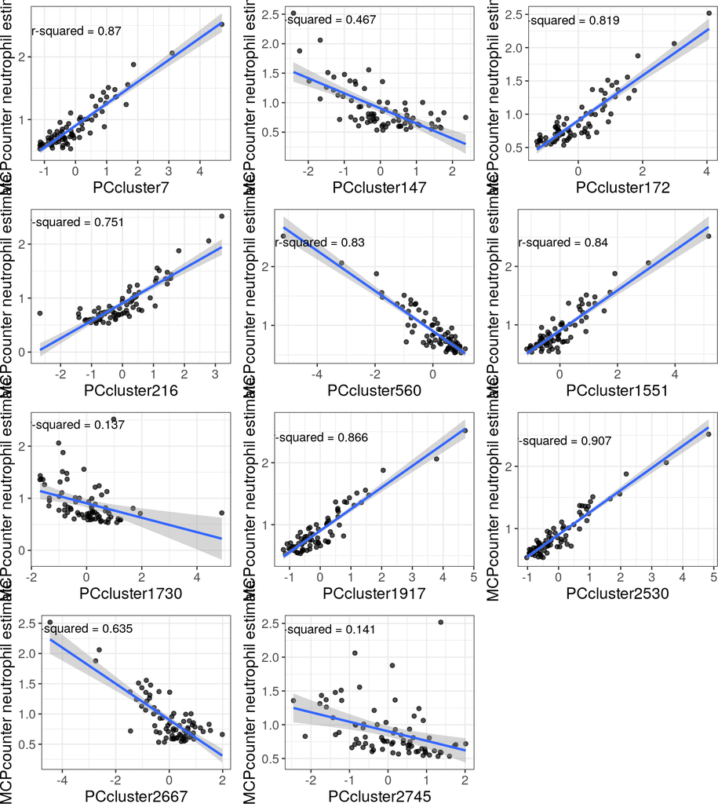

```r
plots <- list()
for (i in seq_along(sig_ind)) {
  plot <- LVScatter(dat2, paste0("PCcluster", sig_ind[i]),
                    y.var = "MCP_estimate",
                    ylab = "MCPcounter neutrophil estimate")
  plots[[i]] <- plot
}

gridExtra::grid.arrange(grobs = plots, cols = 2)
```